# Breast Cancer Wisconsin Dataset

Aravind

April 2, 2018

# Data Cancer Diagnosis

## Dataset Overview

The Breast Cancer (Wisconsin) dataset used in this paper is publicly available in the UCI machine learning repository and was created by Dr. William H. Wolberg, Dr. W. Nick Street, and Olvi L. Mangasarian. The doner is W. Nick Street. The dataset is created by Dr. Wolberg by taking suspected tumor samples via a thin needle from patient’s solid breast masses and the samples are placed on dent-shaped glass slides. The slide is dent shaped in order to distinguish the nearby cells with the tumor cells. The collected tissue samples are then examined under microscope and features are computed from the digitized image of a fine needle aspirate (FNA) of breast mass. This is done via a graphical computer program, which is capable of performing the analysis of cytological features based on a digital scan.

Dataset: [Breast Cancer (Wisconsin) dataset](http://archive.ics.uci.edu/ml/datasets/breast+cancer+wisconsin+%28diagnostic%29)

This is a classification dataset consisting of:

- 569 Instances
- 32 features
- No missing values

The attributes are:

1. ID number
2. Diagnosis (M = malignant, B = benign)
3. (3-32) Ten real-valued features are computed for each cell nucleus:
1. radius (mean of distances from center to points on the perimeter)
2. texture (standard deviation of gray-scale values)
3. perimeter
4. area
5. smoothness (local variation in radius lengths)
6. compactness (perimeter^2 / area - 1.0)
7. concavity (severity of concave portions of the contour)
8. concave points (number of concave portions of the contour)
9. symmetry
10. fractal dimension (“coastline approximation” - 1)

## Analysis

### Required Packages

```r
library(dplyr)
```

```r
library(magrittr)
library(corrplot)
library(kernlab)
library(pROC)
library(rpart)
library(MASS)
library(caret)
library(caTools)
library(ranger)
library(e1071)
library(randomForest)
library(tidyverse)
```

### Loading the data

```r
data <- read.csv(".//data.csv", header =TRUE)
dim(data)
```

```
## [1] 569  33
```

```r
head(data)
```

```
##         id diagnosis radius_mean texture_mean perimeter_mean area_mean
## 1   842302         M       17.99        10.38         122.80    1001.0
## 2   842517         M       20.57        17.77         132.90    1326.0
## 3 84300903         M       19.69        21.25         130.00    1203.0
## 4 84348301         M       11.42        20.38          77.58     386.1
## 5 84358402         M       20.29        14.34         135.10    1297.0
## 6   843786         M       12.45        15.70          82.57     477.1
##   smoothness_mean compactness_mean concavity_mean concave.points_mean
## 1         0.11840          0.27760         0.3001             0.14710
## 2         0.08474          0.07864         0.0869             0.07017
## 3         0.10960          0.15990         0.1974             0.12790
## 4         0.14250          0.28390         0.2414             0.10520
## 5         0.10030          0.13280         0.1980             0.10430
## 6         0.12780          0.17000         0.1578             0.08089
##   symmetry_mean fractal_dimension_mean radius_se texture_se perimeter_se
```

[output cut: 41 more lines]

```r
str(data)
```

```
## 'data.frame':    569 obs. of  33 variables:
##  $ id                     : int  842302 842517 84300903 84348301 84358402 843786 844359 84458202 844981 84501001 ...
##  $ diagnosis              : Factor w/ 2 levels "B","M": 2 2 2 2 2 2 2 2 2 2 ...
##  $ radius_mean            : num  18 20.6 19.7 11.4 20.3 ...
##  $ texture_mean           : num  10.4 17.8 21.2 20.4 14.3 ...
##  $ perimeter_mean         : num  122.8 132.9 130 77.6 135.1 ...
##  $ area_mean              : num  1001 1326 1203 386 1297 ...
##  $ smoothness_mean        : num  0.1184 0.0847 0.1096 0.1425 0.1003 ...
##  $ compactness_mean       : num  0.2776 0.0786 0.1599 0.2839 0.1328 ...
##  $ concavity_mean         : num  0.3001 0.0869 0.1974 0.2414 0.198 ...
##  $ concave.points_mean    : num  0.1471 0.0702 0.1279 0.1052 0.1043 ...
##  $ symmetry_mean          : num  0.242 0.181 0.207 0.26 0.181 ...
##  $ fractal_dimension_mean : num  0.0787 0.0567 0.06 0.0974 0.0588 ...
##  $ radius_se              : num  1.095 0.543 0.746 0.496 0.757 ...
##  $ texture_se             : num  0.905 0.734 0.787 1.156 0.781 ...
```

[output cut: 19 more lines]

### Data Pre-Processing

Looking at the data, we can remove the 33rd column since all values in this column are “NA”. Also, we can remove id column as it plays no part in predicting the diagnosis. Change the column number 2 into facor.

```r
data$diagnosis <- as.factor(data$diagnosis)
cleaned_dataset <- data[,3:32]
head(cleaned_dataset)
```

```
##   radius_mean texture_mean perimeter_mean area_mean smoothness_mean
## 1       17.99        10.38         122.80    1001.0         0.11840
## 2       20.57        17.77         132.90    1326.0         0.08474
## 3       19.69        21.25         130.00    1203.0         0.10960
## 4       11.42        20.38          77.58     386.1         0.14250
## 5       20.29        14.34         135.10    1297.0         0.10030
## 6       12.45        15.70          82.57     477.1         0.12780
##   compactness_mean concavity_mean concave.points_mean symmetry_mean
## 1          0.27760         0.3001             0.14710        0.2419
## 2          0.07864         0.0869             0.07017        0.1812
## 3          0.15990         0.1974             0.12790        0.2069
## 4          0.28390         0.2414             0.10520        0.2597
## 5          0.13280         0.1980             0.10430        0.1809
## 6          0.17000         0.1578             0.08089        0.2087
##   fractal_dimension_mean radius_se texture_se perimeter_se area_se
```

[output cut: 34 more lines]

```r
str(cleaned_dataset)
```

```
## 'data.frame':    569 obs. of  30 variables:
##  $ radius_mean            : num  18 20.6 19.7 11.4 20.3 ...
##  $ texture_mean           : num  10.4 17.8 21.2 20.4 14.3 ...
##  $ perimeter_mean         : num  122.8 132.9 130 77.6 135.1 ...
##  $ area_mean              : num  1001 1326 1203 386 1297 ...
##  $ smoothness_mean        : num  0.1184 0.0847 0.1096 0.1425 0.1003 ...
##  $ compactness_mean       : num  0.2776 0.0786 0.1599 0.2839 0.1328 ...
##  $ concavity_mean         : num  0.3001 0.0869 0.1974 0.2414 0.198 ...
##  $ concave.points_mean    : num  0.1471 0.0702 0.1279 0.1052 0.1043 ...
##  $ symmetry_mean          : num  0.242 0.181 0.207 0.26 0.181 ...
##  $ fractal_dimension_mean : num  0.0787 0.0567 0.06 0.0974 0.0588 ...
##  $ radius_se              : num  1.095 0.543 0.746 0.496 0.757 ...
##  $ texture_se             : num  0.905 0.734 0.787 1.156 0.781 ...
##  $ perimeter_se           : num  8.59 3.4 4.58 3.44 5.44 ...
##  $ area_se                : num  153.4 74.1 94 27.2 94.4 ...
```

[output cut: 16 more lines]

### Data Visualization

```r
round(prop.table(table(data$diagnosis)), 2)
```

```
##
##    B    M
## 0.63 0.37
```

Checking for coorelation using findcorrelation function from the caret package with cutoff of 90%.

```r
corr_mat <- round(cor(cleaned_dataset, method = "pearson"),1)
df2 <- cleaned_dataset %>%
  dplyr::select(-findCorrelation(corr_mat, cutoff = 0.9))
dim(df2)
```

```
## [1] 569  24
```

```r
colnames(df2)
```

```
##  [1] "radius_mean"             "texture_mean"
##  [3] "smoothness_mean"         "compactness_mean"
##  [5] "concavity_mean"          "concave.points_mean"
##  [7] "symmetry_mean"           "fractal_dimension_mean"
##  [9] "radius_se"               "texture_se"
## [11] "smoothness_se"           "compactness_se"
## [13] "concavity_se"            "concave.points_se"
## [15] "symmetry_se"             "fractal_dimension_se"
## [17] "texture_worst"           "area_worst"
## [19] "smoothness_worst"        "compactness_worst"
## [21] "concavity_worst"         "concave.points_worst"
## [23] "symmetry_worst"          "fractal_dimension_worst"
```

```r
colnames(cleaned_dataset)
```

```
##  [1] "radius_mean"             "texture_mean"
##  [3] "perimeter_mean"          "area_mean"
##  [5] "smoothness_mean"         "compactness_mean"
##  [7] "concavity_mean"          "concave.points_mean"
##  [9] "symmetry_mean"           "fractal_dimension_mean"
## [11] "radius_se"               "texture_se"
## [13] "perimeter_se"            "area_se"
## [15] "smoothness_se"           "compactness_se"
## [17] "concavity_se"            "concave.points_se"
## [19] "symmetry_se"             "fractal_dimension_se"
## [21] "radius_worst"            "texture_worst"
## [23] "perimeter_worst"         "area_worst"
## [25] "smoothness_worst"        "compactness_worst"
## [27] "concavity_worst"         "concave.points_worst"
## [29] "symmetry_worst"          "fractal_dimension_worst"
```

Correlation Plot

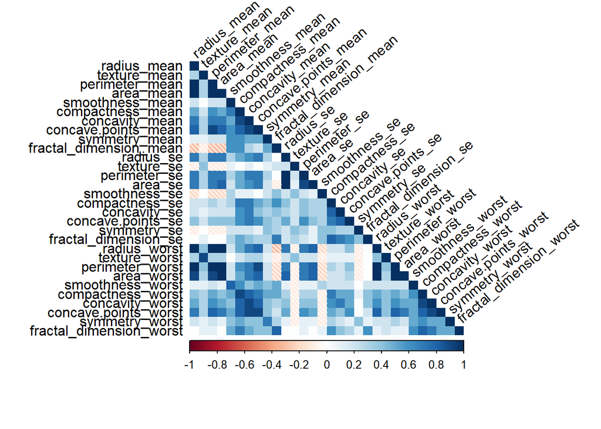

```r
## Correlation plot for original dataset
corrplot(corr_mat, tl.col = "black", method = "shade",type = "lower",mar=c(0,1,0,1), tl.srt = 40)
```

From the correlation plot, we can see that the dataset consists of highly correlated features, therefore some of the highly correlated features are to be removed.

### Dimension Reduction

```r
df3 <- cleaned_dataset[,c(4,5,6,9,10,11,12,15,16,17,18,19,20,22,25,26,27,28,29,30)]
dim(df3)
```

```
## [1] 569  20
```

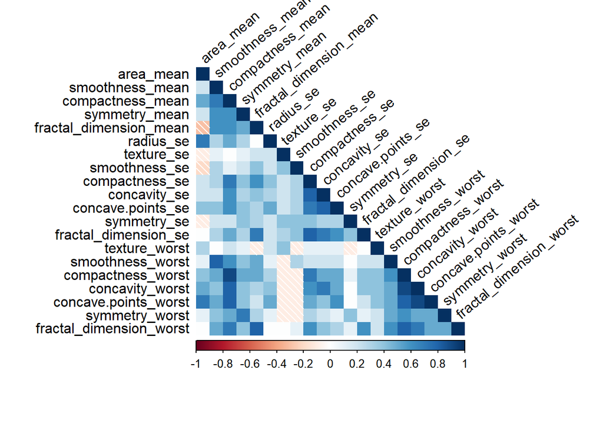

```r
## Correlation plot for cleaned dataset
corrplot(round(cor(df3),1), tl.col = "black", method = "shade", type = "lower",mar=c(0,1,0,1), tl.srt = 40)
```

### Training and Testing dataset

```r
df4 <- cbind(diagnosis = data$diagnosis, df3)
head(df4)
```

```
##   diagnosis area_mean smoothness_mean compactness_mean symmetry_mean
## 1         M    1001.0         0.11840          0.27760        0.2419
## 2         M    1326.0         0.08474          0.07864        0.1812
## 3         M    1203.0         0.10960          0.15990        0.2069
## 4         M     386.1         0.14250          0.28390        0.2597
## 5         M    1297.0         0.10030          0.13280        0.1809
## 6         M     477.1         0.12780          0.17000        0.2087
##   fractal_dimension_mean radius_se texture_se smoothness_se compactness_se
## 1                0.07871    1.0950     0.9053      0.006399        0.04904
## 2                0.05667    0.5435     0.7339      0.005225        0.01308
## 3                0.05999    0.7456     0.7869      0.006150        0.04006
## 4                0.09744    0.4956     1.1560      0.009110        0.07458
## 5                0.05883    0.7572     0.7813      0.011490        0.02461
## 6                0.07613    0.3345     0.8902      0.007510        0.03345
##   concavity_se concave.points_se symmetry_se fractal_dimension_se
```

[output cut: 20 more lines]

```r
str(df4)
```

```
## 'data.frame':    569 obs. of  21 variables:
##  $ diagnosis              : Factor w/ 2 levels "B","M": 2 2 2 2 2 2 2 2 2 2 ...
##  $ area_mean              : num  1001 1326 1203 386 1297 ...
##  $ smoothness_mean        : num  0.1184 0.0847 0.1096 0.1425 0.1003 ...
##  $ compactness_mean       : num  0.2776 0.0786 0.1599 0.2839 0.1328 ...
##  $ symmetry_mean          : num  0.242 0.181 0.207 0.26 0.181 ...
##  $ fractal_dimension_mean : num  0.0787 0.0567 0.06 0.0974 0.0588 ...
##  $ radius_se              : num  1.095 0.543 0.746 0.496 0.757 ...
##  $ texture_se             : num  0.905 0.734 0.787 1.156 0.781 ...
##  $ smoothness_se          : num  0.0064 0.00522 0.00615 0.00911 0.01149 ...
##  $ compactness_se         : num  0.049 0.0131 0.0401 0.0746 0.0246 ...
##  $ concavity_se           : num  0.0537 0.0186 0.0383 0.0566 0.0569 ...
##  $ concave.points_se      : num  0.0159 0.0134 0.0206 0.0187 0.0188 ...
##  $ symmetry_se            : num  0.03 0.0139 0.0225 0.0596 0.0176 ...
##  $ fractal_dimension_se   : num  0.00619 0.00353 0.00457 0.00921 0.00511 ...
##  $ texture_worst          : num  17.3 23.4 25.5 26.5 16.7 ...
##  $ smoothness_worst       : num  0.162 0.124 0.144 0.21 0.137 ...
##  $ compactness_worst      : num  0.666 0.187 0.424 0.866 0.205 ...
##  $ concavity_worst        : num  0.712 0.242 0.45 0.687 0.4 ...
##  $ concave.points_worst   : num  0.265 0.186 0.243 0.258 0.163 ...
##  $ symmetry_worst         : num  0.46 0.275 0.361 0.664 0.236 ...
##  $ fractal_dimension_worst: num  0.1189 0.089 0.0876 0.173 0.0768 ...
```

```r
set.seed(1234)
data_index <- createDataPartition(df4$diagnosis, p=0.7, list = FALSE)
train_data <- df4[data_index,]
test_data <- df4[-data_index,]
```

### Principle Component Analysis

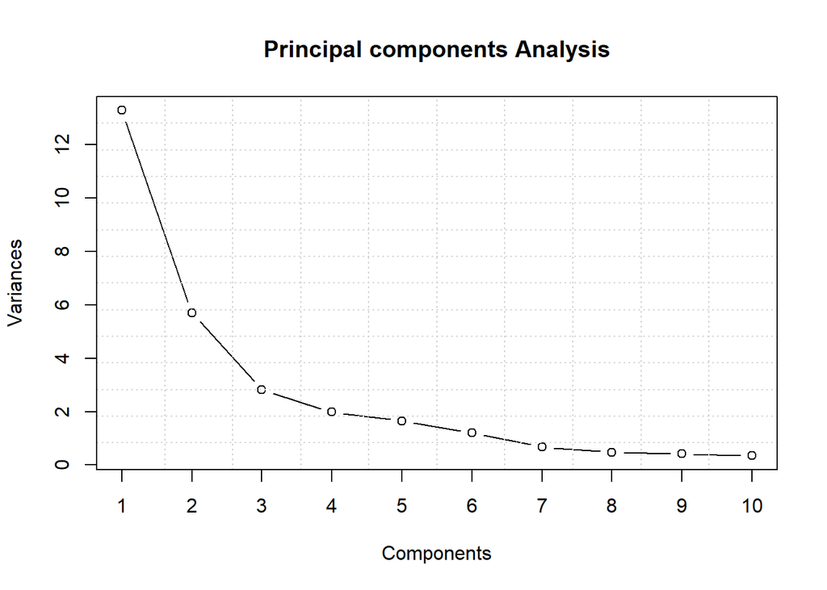

```r
PCA_Graph <- prcomp(cleaned_dataset, center = TRUE, scale = TRUE)
plot(PCA_Graph, type="l", main = " ")
grid(nx = 10, ny = 14)
title(main = "Principal components Analysis", sub = NULL, xlab = "Components")
box()
```

```r
summary(PCA_Graph)
```

```
## Importance of components:
##                           PC1    PC2     PC3     PC4     PC5     PC6
## Standard deviation     3.6444 2.3857 1.67867 1.40735 1.28403 1.09880
## Proportion of Variance 0.4427 0.1897 0.09393 0.06602 0.05496 0.04025
## Cumulative Proportion  0.4427 0.6324 0.72636 0.79239 0.84734 0.88759
##                            PC7     PC8    PC9    PC10   PC11    PC12
## Standard deviation     0.82172 0.69037 0.6457 0.59219 0.5421 0.51104
## Proportion of Variance 0.02251 0.01589 0.0139 0.01169 0.0098 0.00871
## Cumulative Proportion  0.91010 0.92598 0.9399 0.95157 0.9614 0.97007
##                           PC13    PC14    PC15    PC16    PC17    PC18
## Standard deviation     0.49128 0.39624 0.30681 0.28260 0.24372 0.22939
## Proportion of Variance 0.00805 0.00523 0.00314 0.00266 0.00198 0.00175
## Cumulative Proportion  0.97812 0.98335 0.98649 0.98915 0.99113 0.99288
##                           PC19    PC20   PC21    PC22    PC23   PC24
## Standard deviation     0.22244 0.17652 0.1731 0.16565 0.15602 0.1344
## Proportion of Variance 0.00165 0.00104 0.0010 0.00091 0.00081 0.0006
## Cumulative Proportion  0.99453 0.99557 0.9966 0.99749 0.99830 0.9989
##                           PC25    PC26    PC27    PC28    PC29    PC30
## Standard deviation     0.12442 0.09043 0.08307 0.03987 0.02736 0.01153
## Proportion of Variance 0.00052 0.00027 0.00023 0.00005 0.00002 0.00000
## Cumulative Proportion  0.99942 0.99969 0.99992 0.99997 1.00000 1.00000
```

The first 10 PCA’s account for 95% of the information, and 17 PCA,s account for 99% of the information.

### Machine learning models

```r
## Threshold for pca preprocess = 0.99
fitControl <- trainControl(method="cv",
                           number = 5,
                           preProcOptions = list(thresh = 0.99),
                           classProbs = TRUE,
                           summaryFunction = twoClassSummary)
```

## Supply Vector Machine(SVM) Radial

```r
model_svm <- train(diagnosis~.,
                   train_data,
                   method="svmRadial",
                   metric="ROC",
                   preProcess=c('center', 'scale'),
                   trace=FALSE,
                   trControl=fitControl)
pred_svm <- predict(model_svm, test_data)
cm_svm <- confusionMatrix(pred_svm, test_data$diagnosis, positive = "M")
cm_svm
```

```
## Confusion Matrix and Statistics
##
##           Reference
## Prediction   B   M
##          B 104   1
##          M   3  62
##
##                Accuracy : 0.9765
##                  95% CI : (0.9409, 0.9936)
##     No Information Rate : 0.6294
##     P-Value [Acc > NIR] : <2e-16
##
##                   Kappa : 0.9499
##  Mcnemar's Test P-Value : 0.6171
##
##             Sensitivity : 0.9841
##             Specificity : 0.9720
##          Pos Pred Value : 0.9538
##          Neg Pred Value : 0.9905
##              Prevalence : 0.3706
##          Detection Rate : 0.3647
##    Detection Prevalence : 0.3824
##       Balanced Accuracy : 0.9780
##
##        'Positive' Class : M
##
```

The Supply Vector Machine Radial model has an prediction accuracy of 0.9765

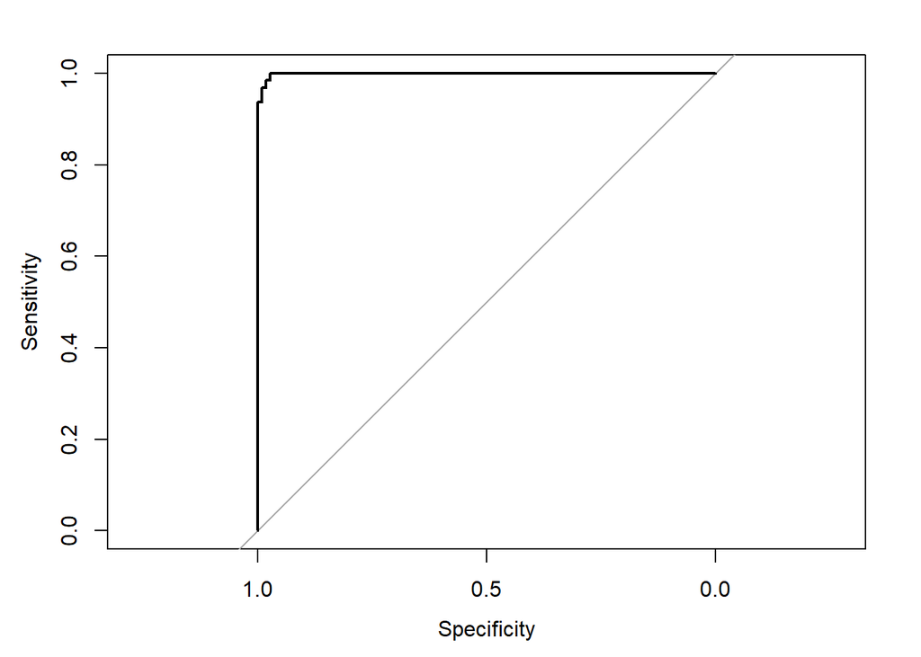

```r
## ROC Curve
pred_prob_R <- predict(model_svm, test_data, type="prob")
roc_R <- roc(test_data$diagnosis, pred_prob_R$M)
plot(roc_R)
```

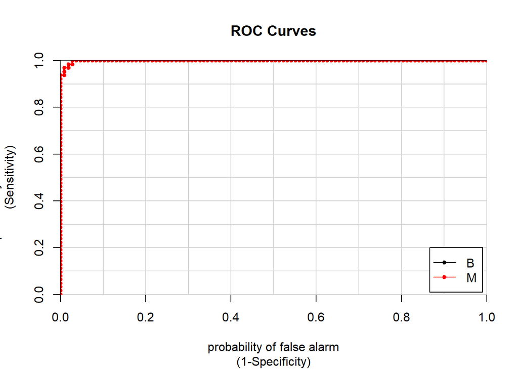

```
##                 B         M
## B vs. M 0.9989616 0.9989616
```

```r
colAUC(pred_prob_R, test_data$diagnosis, plotROC=TRUE)
```

## Supply Vector Machine(SVM) Poly

```r
model_svm2 <- train(diagnosis~.,
                    train_data,
                    method="svmPoly",
                    metric="ROC",
                    preProcess=c('center', 'scale'),
                    trace=FALSE,
                    trControl=fitControl)
pred_svm2 <- predict(model_svm2, test_data)
cm_svm2 <- confusionMatrix(pred_svm2, test_data$diagnosis, positive = "M")
cm_svm2
```

```
## Confusion Matrix and Statistics
##
##           Reference
## Prediction   B   M
##          B 105   5
##          M   2  58
##
##                Accuracy : 0.9588
##                  95% CI : (0.917, 0.9833)
##     No Information Rate : 0.6294
##     P-Value [Acc > NIR] : <2e-16
##
##                   Kappa : 0.9109
##  Mcnemar's Test P-Value : 0.4497
##
##             Sensitivity : 0.9206
##             Specificity : 0.9813
##          Pos Pred Value : 0.9667
##          Neg Pred Value : 0.9545
##              Prevalence : 0.3706
##          Detection Rate : 0.3412
##    Detection Prevalence : 0.3529
##       Balanced Accuracy : 0.9510
##
##        'Positive' Class : M
##
```

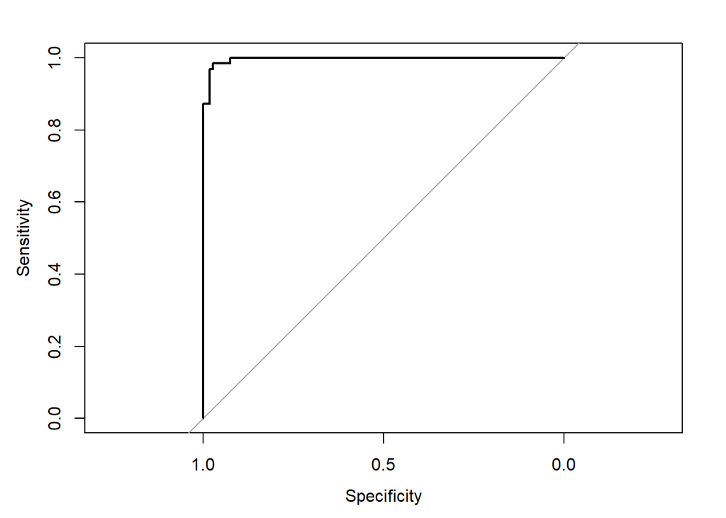

```r
## ROC curve
pred_prob_P <- predict(model_svm2, test_data, type="prob")
roc_P <- roc(test_data$diagnosis, pred_prob_P$M)
plot(roc_P)
```

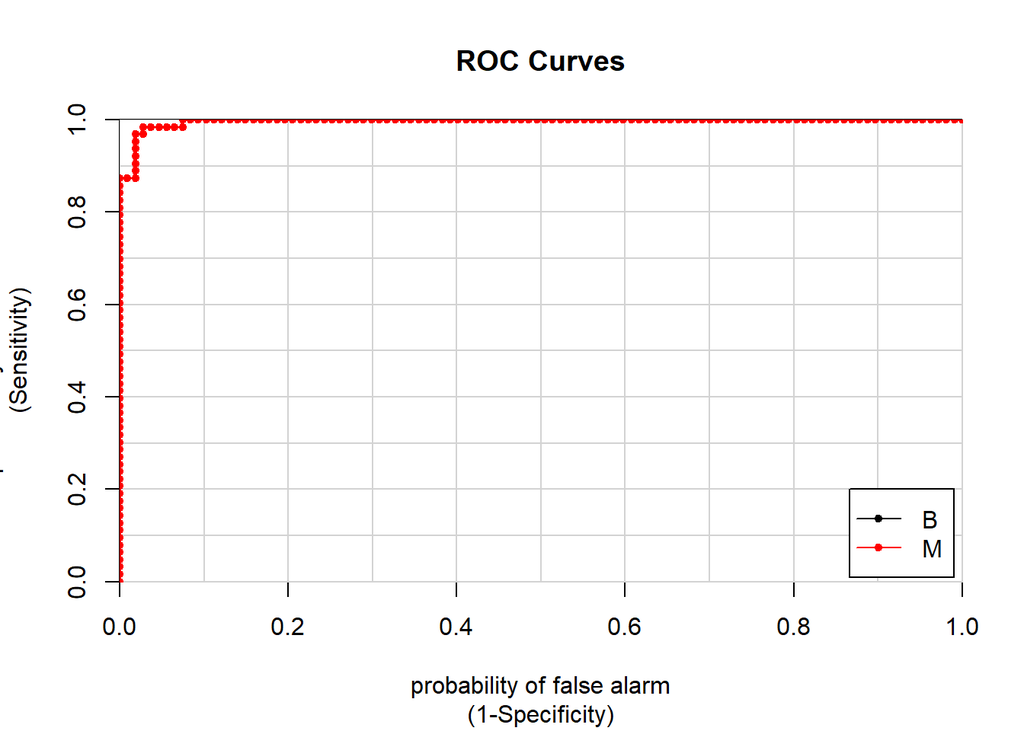

```
##                B        M
## B vs. M 0.996588 0.996588
```

```r
colAUC(pred_prob_P, test_data$diagnosis, plotROC=TRUE)
```

## K-Nearest Neighbour

```r
model_knn <- train(diagnosis~.,
                   train_data,
                   method="knn",
                   metric="ROC",
                   preProcess = c('center', 'scale'),
                   tuneLength=10,
                   trControl=fitControl)
pred_knn <- predict(model_knn, test_data)
cm_knn <- confusionMatrix(pred_knn, test_data$diagnosis, positive = "M")
cm_knn
```

```
## Confusion Matrix and Statistics
##
##           Reference
## Prediction   B   M
##          B 105   6
##          M   2  57
##
##                Accuracy : 0.9529
##                  95% CI : (0.9094, 0.9795)
##     No Information Rate : 0.6294
##     P-Value [Acc > NIR] : <2e-16
##
##                   Kappa : 0.8978
##  Mcnemar's Test P-Value : 0.2888
##
##             Sensitivity : 0.9048
##             Specificity : 0.9813
##          Pos Pred Value : 0.9661
##          Neg Pred Value : 0.9459
##              Prevalence : 0.3706
##          Detection Rate : 0.3353
##    Detection Prevalence : 0.3471
##       Balanced Accuracy : 0.9430
##
##        'Positive' Class : M
##
```

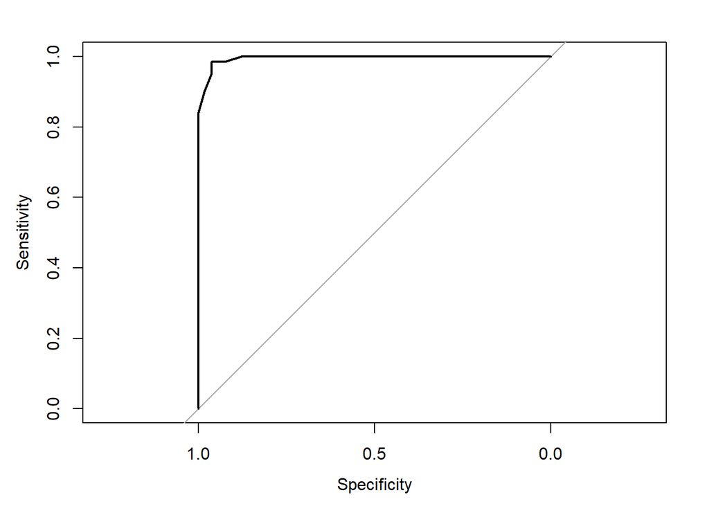

```r
## ROC Curve
pred_prob_knn <- predict(model_knn, test_data, type="prob")
roc_knn <- roc(test_data$diagnosis, pred_prob_knn$M)
plot(roc_knn)
```

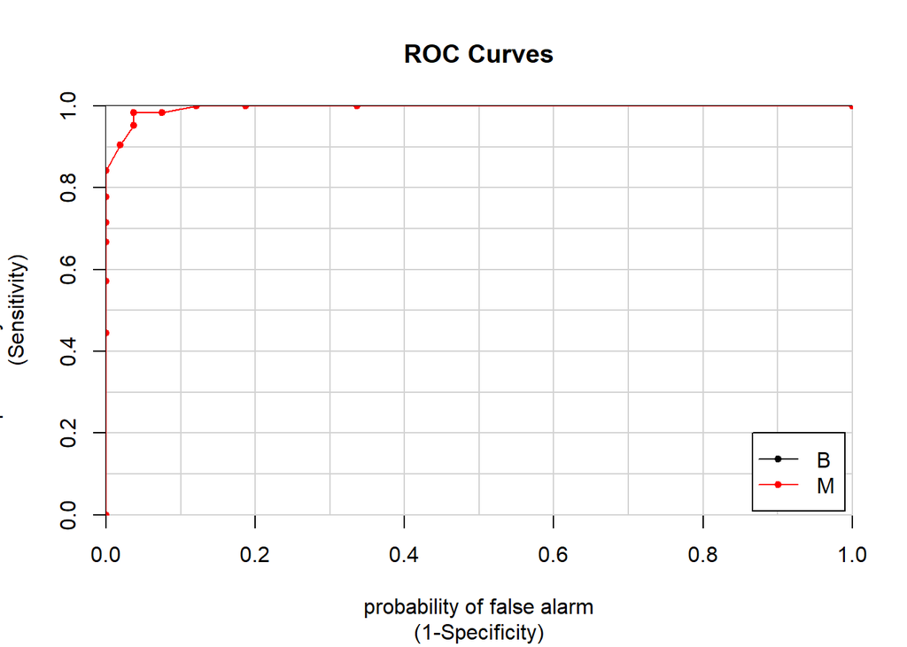

```
##                 B         M
## B vs. M 0.9953271 0.9953271
```

```r
colAUC(pred_prob_knn, test_data$diagnosis, plotROC=TRUE)
```

## Random Forest

```r
model_rf <- train(diagnosis~.,
                  train_data,
                  method="ranger",
                  metric="ROC",
                  tuneLength=10,
                  preProcess = c('center', 'scale'),
                  trControl=fitControl)

pred_rf <- predict(model_rf, test_data)
cm_rf <- confusionMatrix(pred_rf, test_data$diagnosis, positive = "M")
cm_rf
```

```
## Confusion Matrix and Statistics
##
##           Reference
## Prediction   B   M
##          B 104   2
##          M   3  61
##
##                Accuracy : 0.9706
##                  95% CI : (0.9327, 0.9904)
##     No Information Rate : 0.6294
##     P-Value [Acc > NIR] : <2e-16
##
##                   Kappa : 0.9372
##  Mcnemar's Test P-Value : 1
##
##             Sensitivity : 0.9683
##             Specificity : 0.9720
##          Pos Pred Value : 0.9531
##          Neg Pred Value : 0.9811
##              Prevalence : 0.3706
##          Detection Rate : 0.3588
##    Detection Prevalence : 0.3765
##       Balanced Accuracy : 0.9701
##
##        'Positive' Class : M
##
```

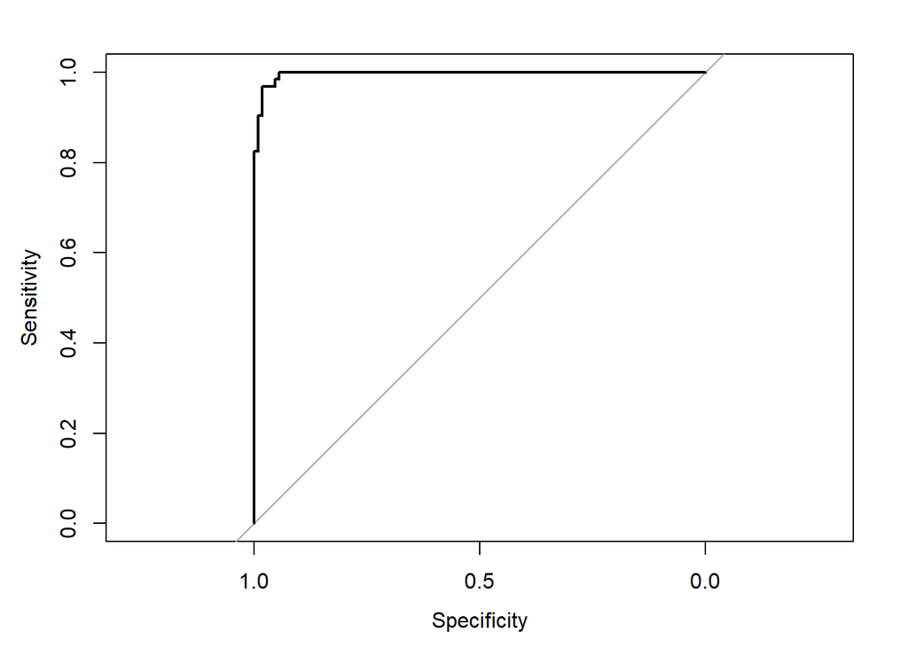

```r
## ROC Curve
pred_prob_rf <- predict(model_rf, test_data, type="prob")
roc_rf <- roc(test_data$diagnosis, pred_prob_rf$M)
plot(roc_rf)
```

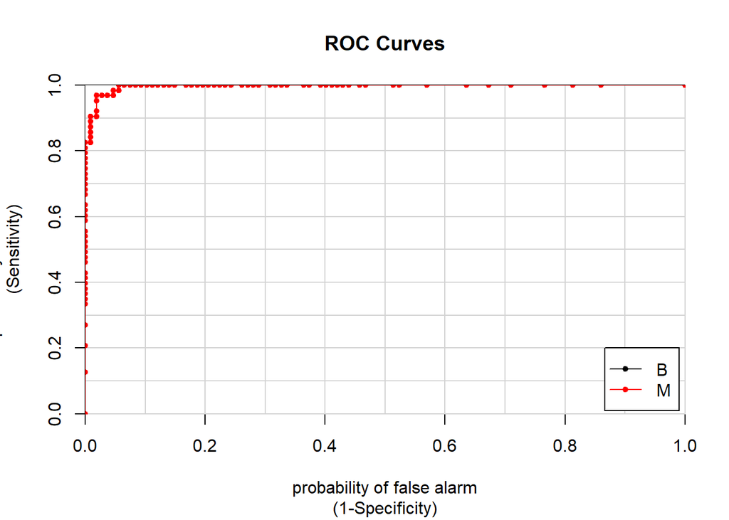

```
##                 B         M
## B vs. M 0.9964397 0.9964397
```

```r
colAUC(pred_prob_rf, test_data$diagnosis, plotROC=TRUE)
```